# modeling terrestrial and arboreal mammals at GPNP

Gene Estrada

2024-05-21

# I. Camera Trap Data

## SPECIES RICHNESS

### Entire Study Area

Excluding arboreal mammals, dogs, and taxa not identified to species level (Muntiacus spp., Tragulus spp. and Unid civets). All camera trap locations: 36 total species.

```
##   SpeciesRichness
## 1              36
```

Compared to only CT locations that have LiDAR data: 34 total species

```
##   SpeciesRichness
## 1              34
```

### By forest type

Excluding arboreal mammals

```
## # A tibble: 7 × 4
##   habitat           n.scanned n.all  diff
##   <ord>                 <int> <int> <int>
## 1 Montane                  22    29     7
## 2 Upland Granite           22    24     2
## 3 Lowland Granite          20    22     2
## 4 Lowland Sandstone        24    27     3
## 5 Alluvial Bench           27    31     4
## 6 Freshwater Swamp         28    31     3
## 7 Peat Swamp               20    23     3
```

### By partition

Excluding unid animals

```
## # A tibble: 11 × 4
##    partition n.scanned n.all  diff
##    <ord>         <int> <int> <int>
##  1 MO2              22    26     4
##  2 UG2              22    23     1
##  3 UG1              14    24    10
##  4 LG2              20    21     1
##  5 LG1              18    20     2
##  6 LS2              19    25     6
##  7 LS1              23    26     3
##  8 AB2              22    27     5
##  9 AB1              21    24     3
## 10 FS1              28    31     3
## 11 PS1              20    23     3
```

### By camera trap location

Excluding arboreal mammals

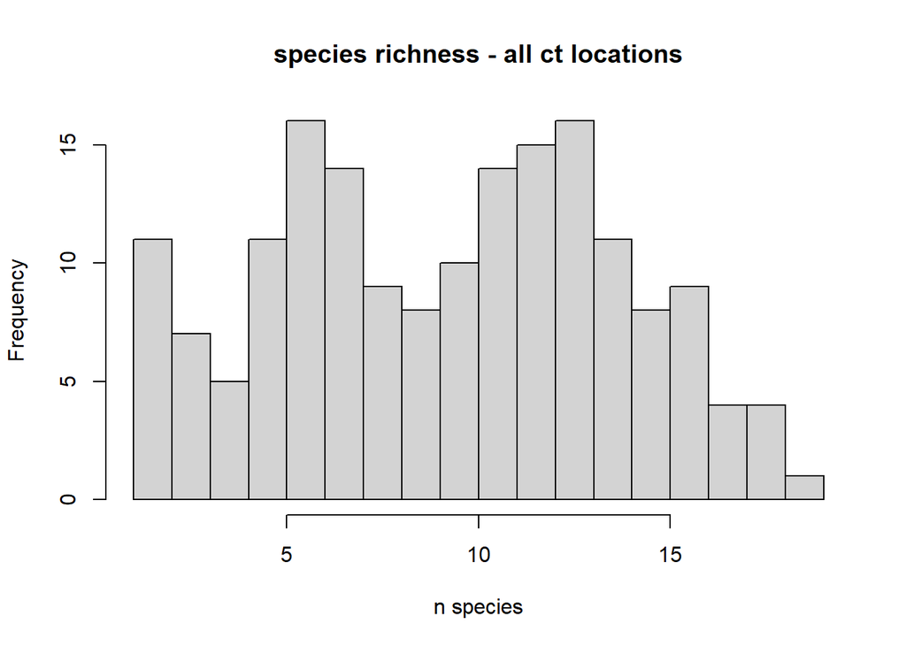

```
##    Min. 1st Qu.  Median    Mean 3rd Qu.    Max.
##   1.000   6.000  10.000   9.659  13.000  19.000
```

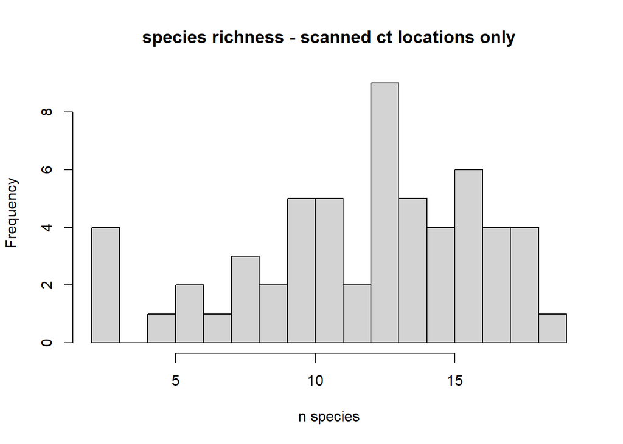

```
##    Min. 1st Qu.  Median    Mean 3rd Qu.    Max.
##    2.00   10.00   13.00   12.21   15.75   19.00
```

## SHANNON DIVERSITY

### By camera trap location

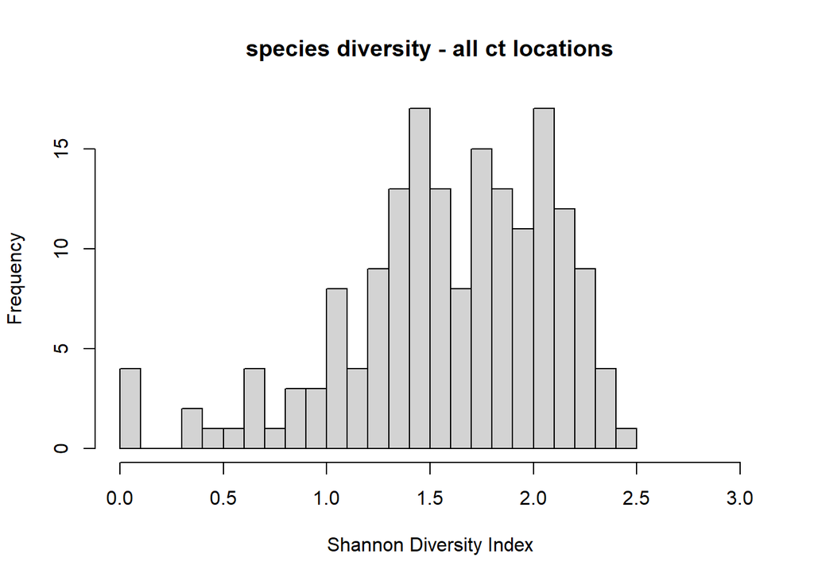

```
##    Min. 1st Qu.  Median    Mean 3rd Qu.    Max.
##   0.000   1.339   1.634   1.589   1.988   2.484
```

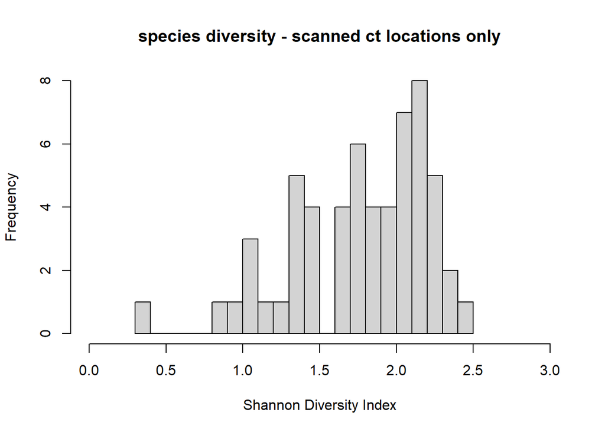

```
##    Min. 1st Qu.  Median    Mean 3rd Qu.    Max.
##  0.3046  1.4367  1.8424  1.7670  2.1257  2.4841
```

### By partition

Comparing Shannon diversity aggregated at partition for all ct locations to only locations with LiDAR data

```
##    partition shannon_all shannon_scan        diff
## 1        PS1    1.668766     1.760385 -0.09161834
## 2        FS1    2.189094     2.100386  0.08870785
## 3        AB1    2.459775     2.435128  0.02464764
## 4        AB2    2.251804     2.282600 -0.03079550
## 5        LS1    2.417306     2.332208  0.08509861
## 6        LS2    2.245537     2.216715  0.02882264
## 7        LG1    2.130200     2.106380  0.02382062
## 8        LG2    2.301889     2.269269  0.03262019
## 9        UG1    1.996149     1.872830  0.12331926
## 10       UG2    2.399767     2.330706  0.06906144
## 11       MO1    2.373866     2.429092 -0.05522585
## 12       MO2    2.340188     2.239893  0.10029504
```

Creating Shannon diversity metrics for terrestrial mammals only, for all partitions and partitions with montane aggregate

### By forest type

```
##             habitat shannon_all shannon_scan        diff
## 1        Peat Swamp    1.668766     1.760385 -0.09161834
## 2  Freshwater Swamp    2.189094     2.100386  0.08870785
## 3    Alluvial Bench    2.380981     2.411738 -0.03075691
## 4 Lowland Sandstone    2.366832     2.337795  0.02903769
## 5   Lowland Granite    2.247289     2.235305  0.01198368
## 6    Upland Granite    2.265847     2.173927  0.09191952
## 7           Montane    2.425421     2.385883  0.03953851
```

## SPECIES EVENNESS

### By camera trap location

Pielou’s diversity measure of species evenness

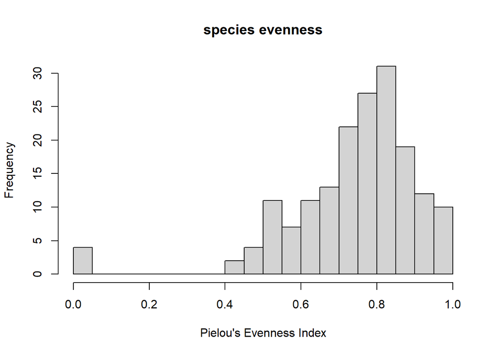

### By partition

Pielou’s diversity measure of species evenness

adding diversity metrics to forest structure metrics df

## FUNCTIONAL DIVERSITY METRICS

### By camera trap location

```
## Species x species distance matrix was not Euclidean. 'sqrt' correction was applied.
## FEVe: Could not be calculated for communities with <3 functionally singular species.
## FDis: Equals 0 in communities with only one functionally singular species.
## FRic: To respect s > t, FRic could not be calculated for communities with <3 functionally singular species.
## FRic: Dimensionality reduction was required. The last 32 PCoA axes (out of 34 in total) were removed.
## FRic: Quality of the reduced-space representation (based on corrected distance matrix) = 0.5079213
## FDiv: Could not be calculated for communities with <3 functionally singular species.
```

### By partition

```
## Species x species distance matrix was not Euclidean. 'sqrt' correction was applied.
## FRic: Dimensionality reduction was required. The last 16 PCoA axes (out of 34 in total) were removed.
## FRic: Quality of the reduced-space representation (based on corrected distance matrix) = 0.9930462
```

#### Correlation between community metrics

By camera trap location:

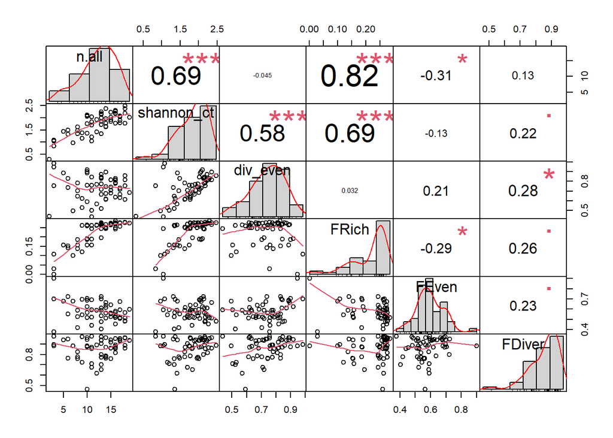

By partition:

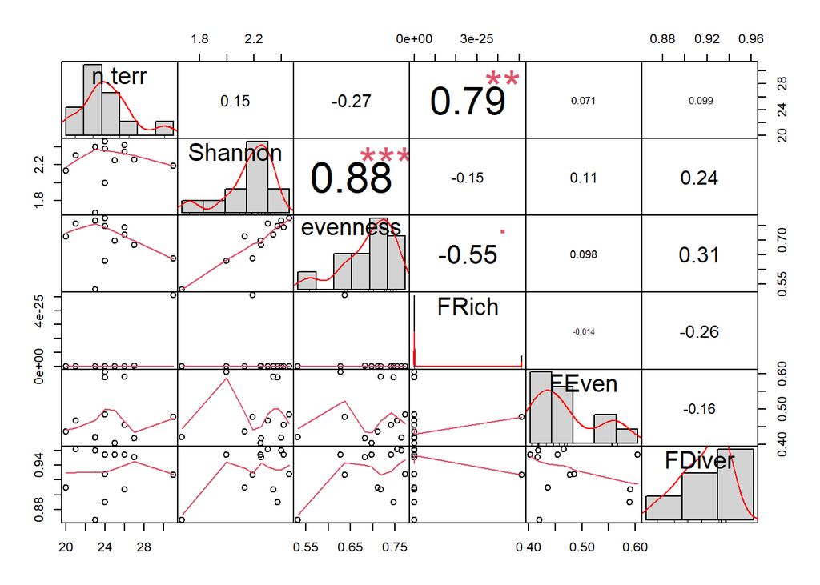

## COMMUNITY METRICS VISUALIZATION

### Community metrics by CT location/forest type

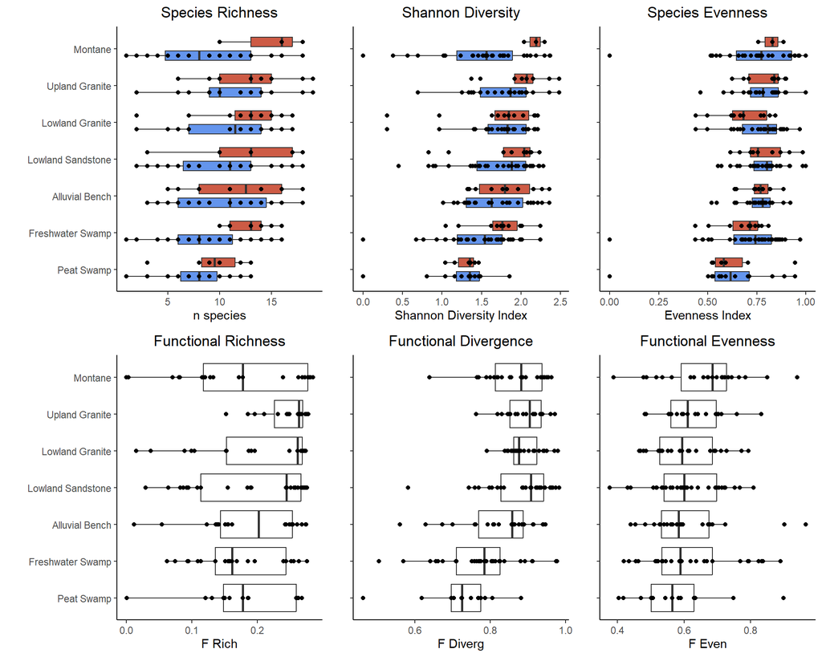

### Community metrics by elevation

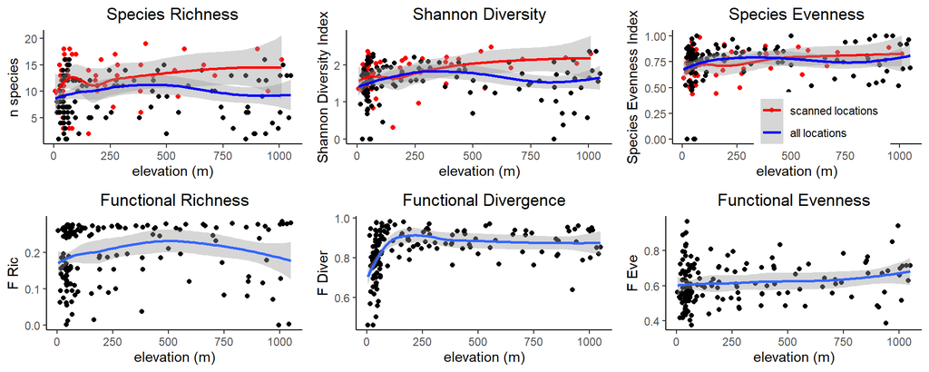

## MODELING - Terrestrial mammals (CT data)

#### Descriptions of forest structure metrics used in models

I used {FORTLS} to extract the following metrics:

1. max.height - maximum height of trees in the stand, in m
2. mean.tree.h - mean tree height in the stand, in m.
3. CRR.rho - canopy relief ratio, using rho for horizontal distance. A measure of canopy variation, with lower scores indicating lower local variation in canopy surface, i.e., more uniform age canopy/ less canopy surface complexity.
4. sd.r - standard deviation of tree heights in stand in m. I’ve seen this value used as an approximation for vertical stratification.
5. mean.dbh - mean diameter at breast height of trees in stand, in cm (measured at height of 1.3m)
6. basal.area - basal area of trees in the stand (m2/ha)
7. stand.dens - density of trees in the stand (trees/ha)
8. stem.vol - volume of trees in the stand (m3/ha)
9. pts.below.2m - shows the number of points in the point cloud that are below 2m.

I used {lidr} and {lidRmetrics} to extract the following metrics:

10. zentropy - normalized Shannon diversity index of z (height) values. Describes vertical complexity.
11. lad.max - Leaf Area Density maximum value for 1m vertical bins. Describes maximum foliage cover of the point cloud.
12. rumple - Rumple index (rugosity), a ratio of the canopy surface area to it’s projected ground area.

vn - number of 1m voxels created for the following volumetric metrics.

13. vFRcanopy - ratio of filled to empty voxels, only counting cells within and below canopy, ignoring above.
14. vzrumple - vertical Rumple index.
15. ClosedGapSpace - volume of voxels that are classified as gaps underneath the canopy

#### Check correlation between predictors.

Basal area is highly correlated (>0.8) with stem volume and stand density.

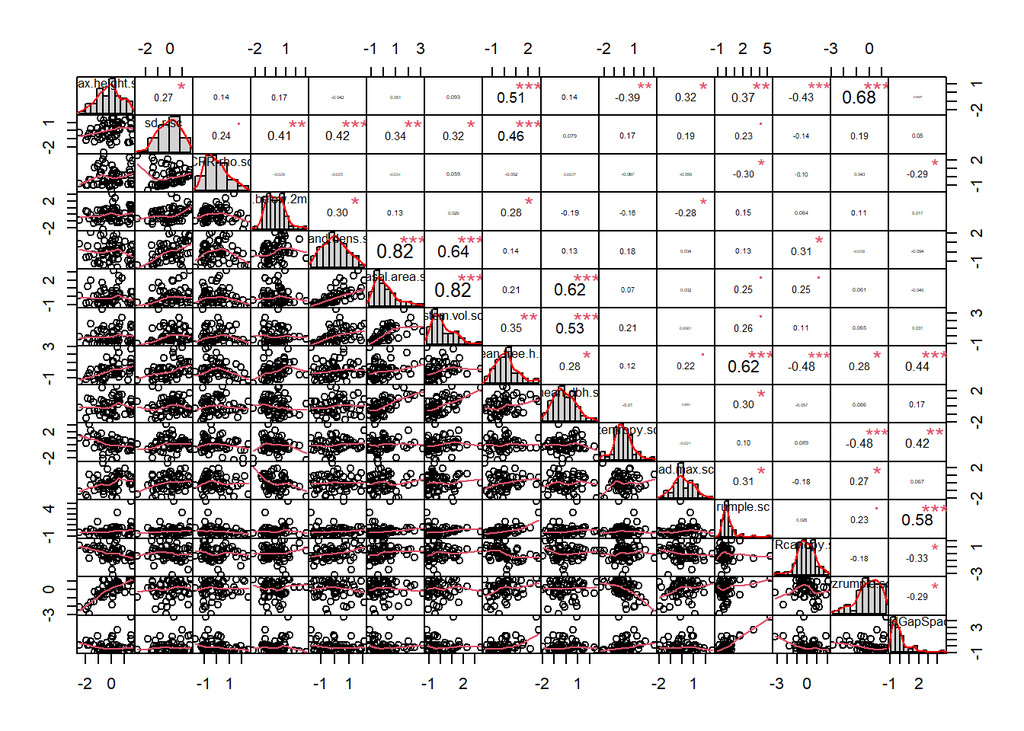

### Models by camera trap location

Fitting global model then using {dredge} to find models of best fit. Restricting models to five predictors to avoid overfitting. Excluding two highly correlated pairs in dredge models: basal area & stand density, and basal area & stem volume.

#### Species richness model

averaged model output - averaging all models

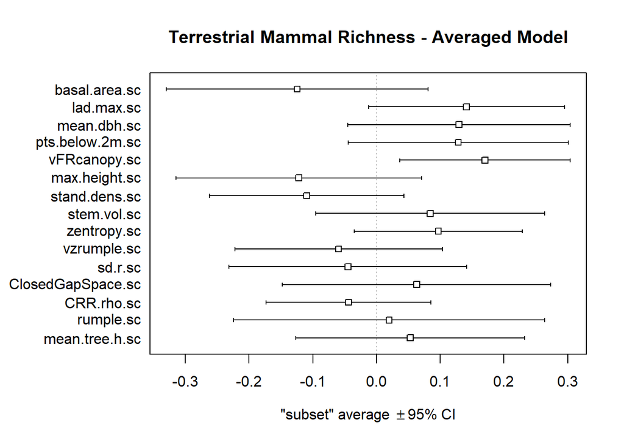

#### Shannon diversity model

averaged model output - averaging all models

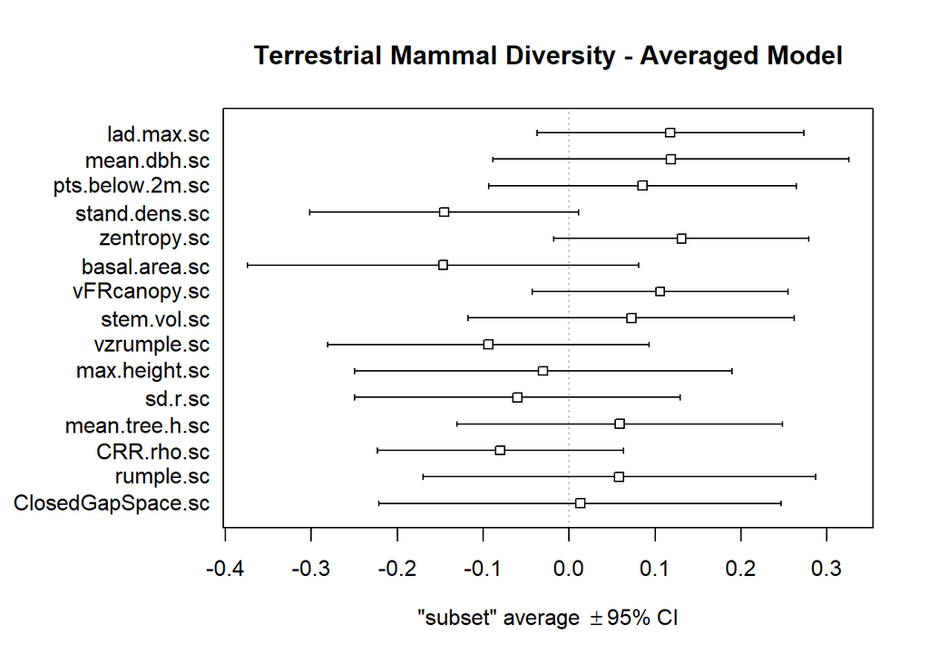

#### Species evenness model

averaged model output - averaging all models

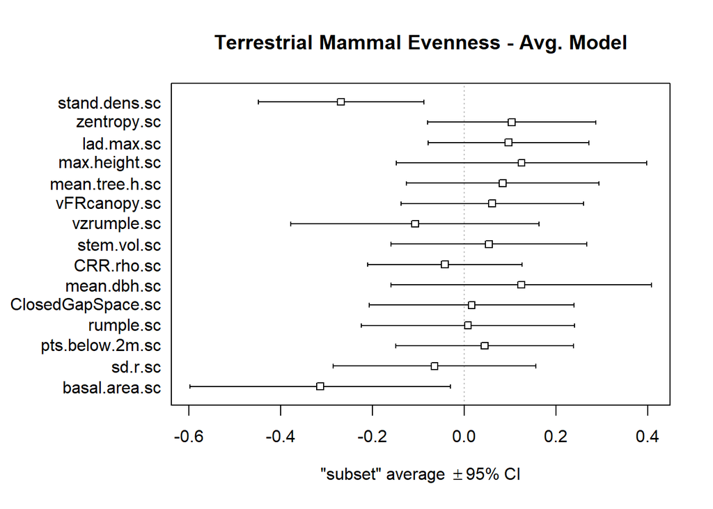

#### Functional richness model

averaged model output - averaging all models

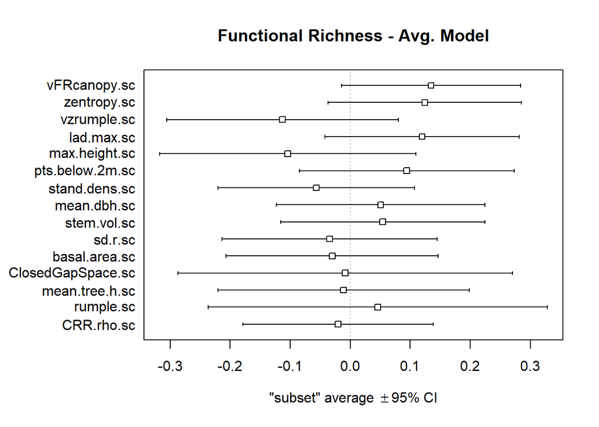

#### Functional evenness model

averaged model output - averaging all models

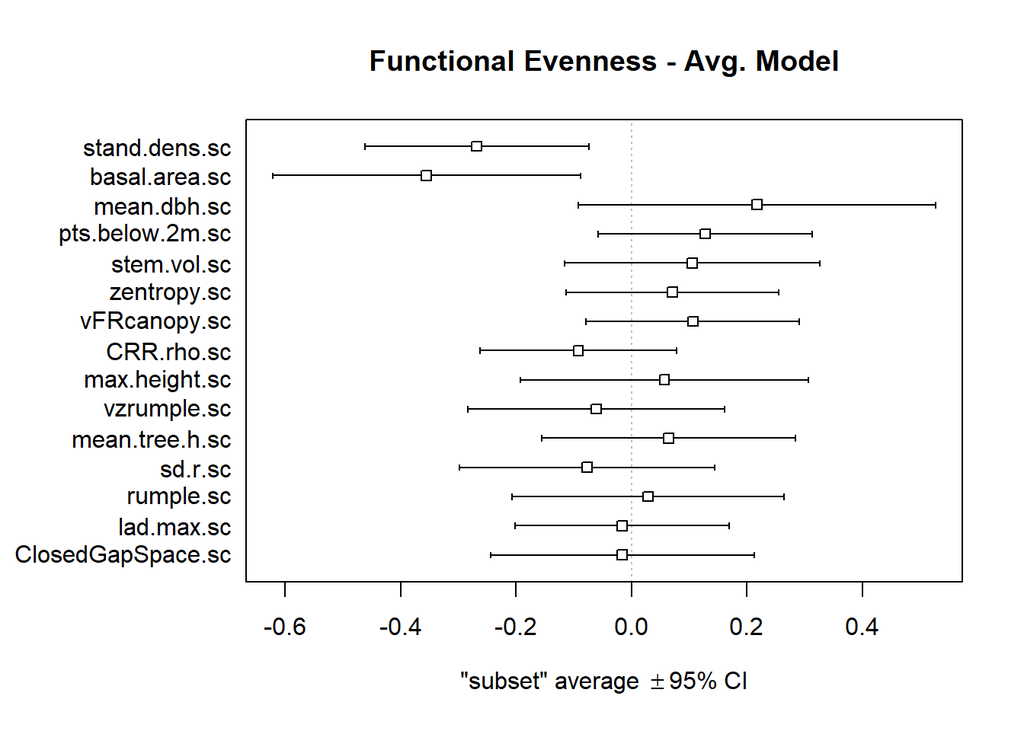

#### Functional divergence model

averaged model output - averaging all models

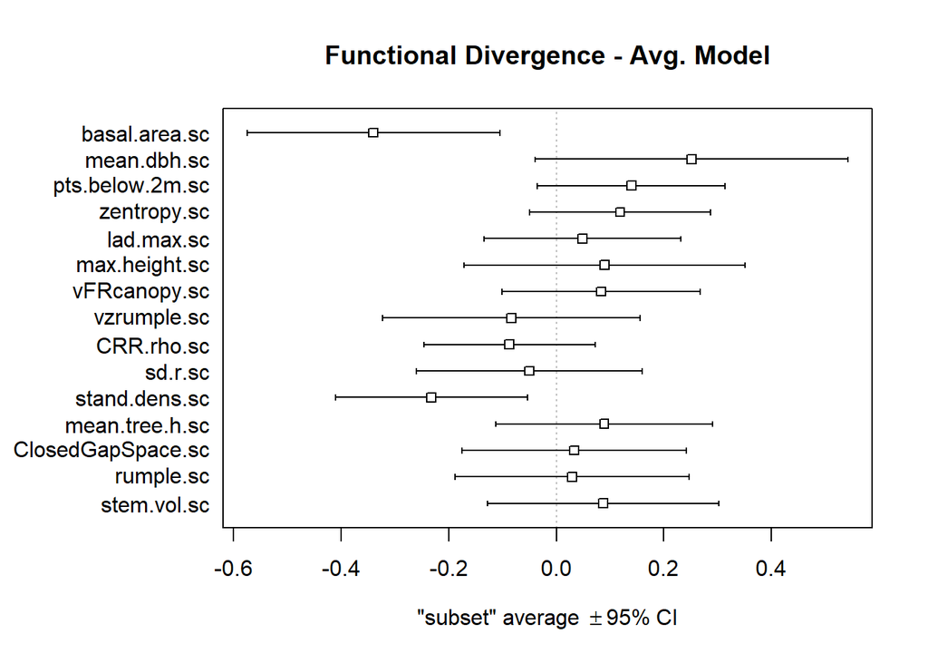

#### Comparing coefficient plot from averaged models

Plotting variables from all models that are reliable predictors only (95% CI’s don’t overlap zero). No reliable predictors in the Shannon Diversity or Functional Richness models. However, in the Shannon model, stand density (neg) and zentropy (pos) were near reliable (CI’s only slightly overlap 0). In the F Rich model this is true for vFRcanopy only (pos), similar to the richness model output.

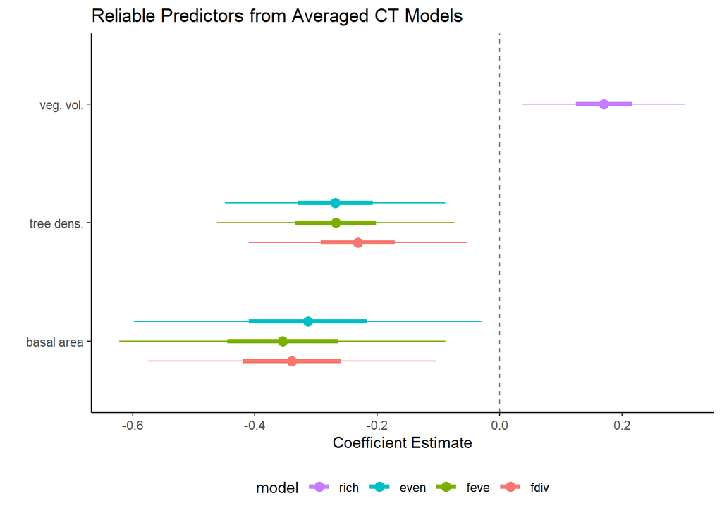

### MODELS BY PARTITION

#### Check correlation between predictors.

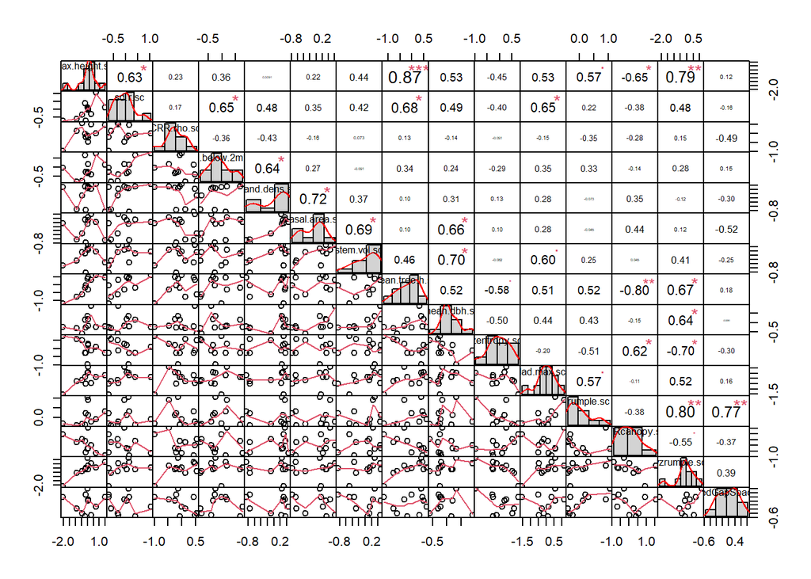

#### Species richness model

Fitting global model then using {dredge} to find models of best fit.

averaged model output - averaging all models

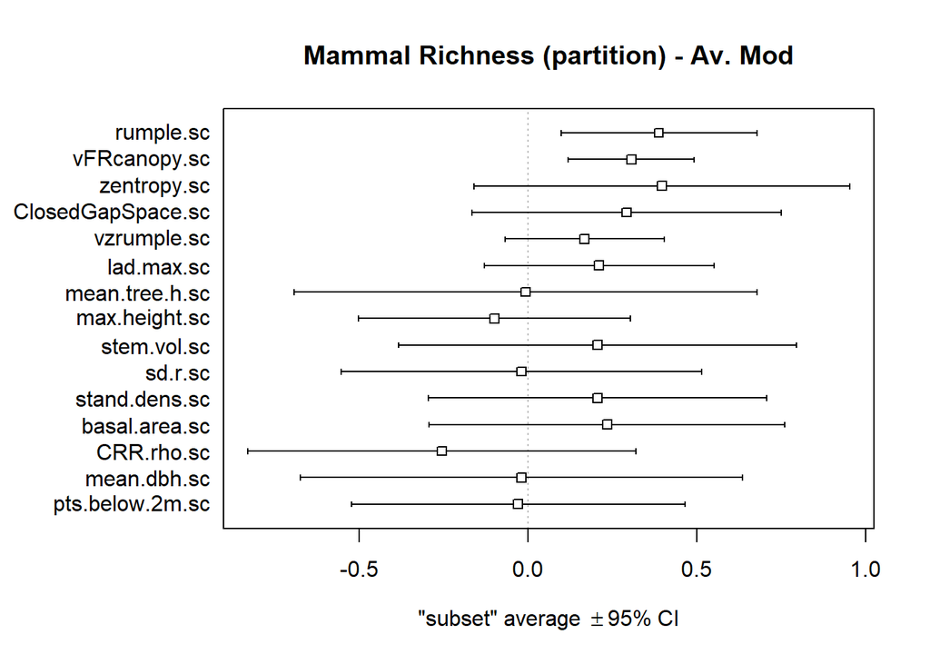

#### Species diversity model

averaged model output - averaging all models

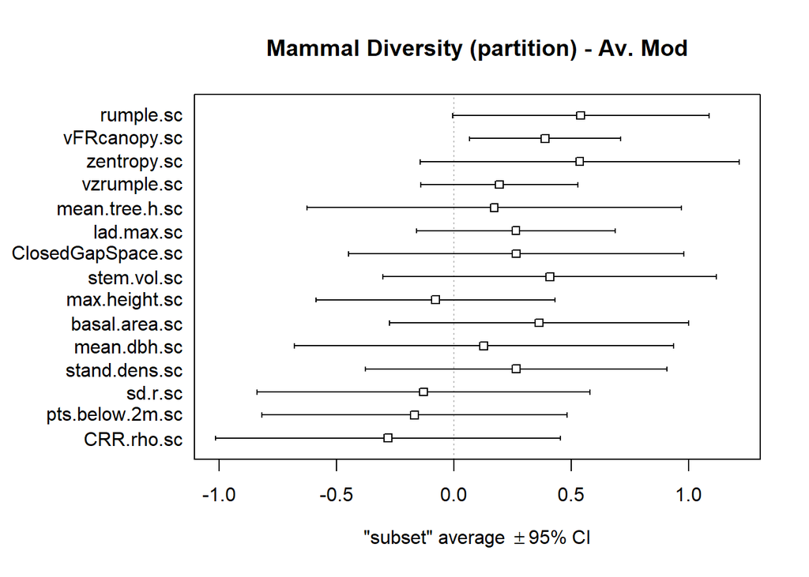

#### Species evenness model

averaged model output - averaging all models

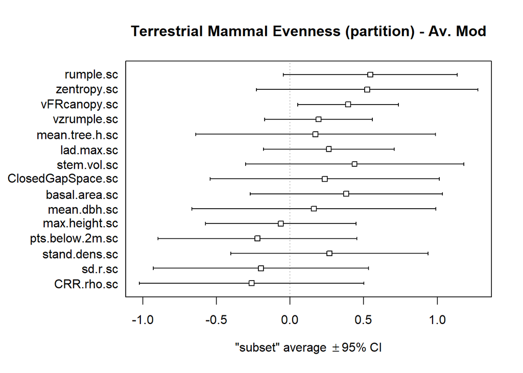

#### Functional richness model

averaged model output - averaging all models

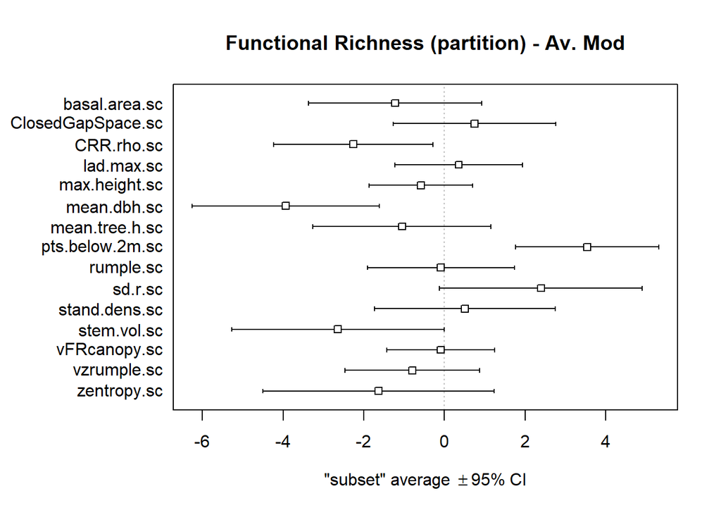

#### Functional evenness model

averaged model output - averaging all models

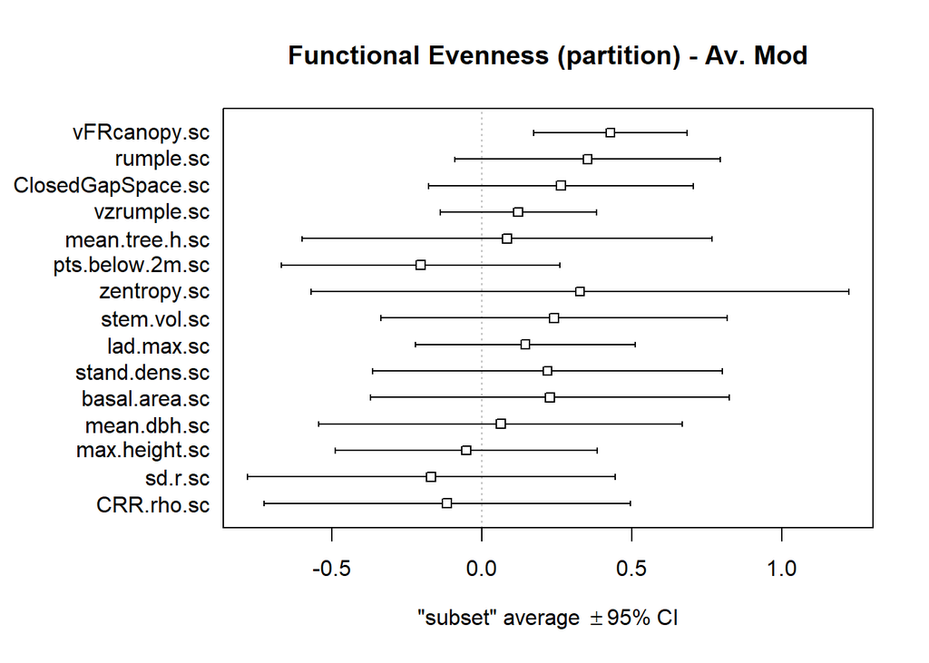

#### Functional divergence model

averaged model output - averaging all models

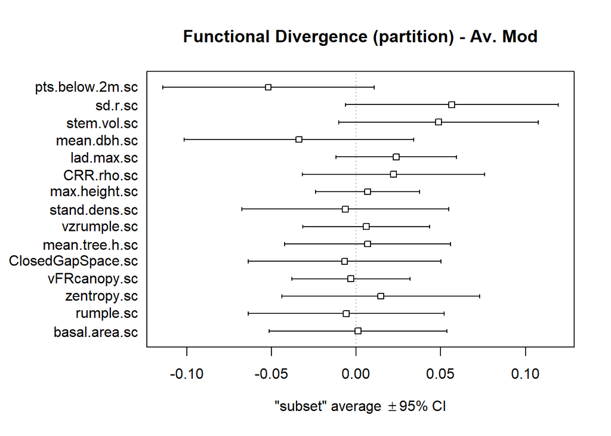

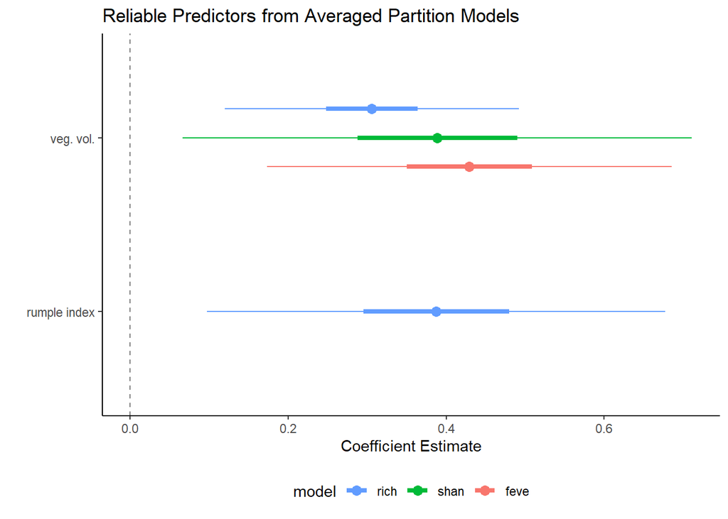

## ORDINATION ANALYSIS

Using PCA to see how scan locations group together and to identify which forest structure metrics best differentiate between forest types and partitions.

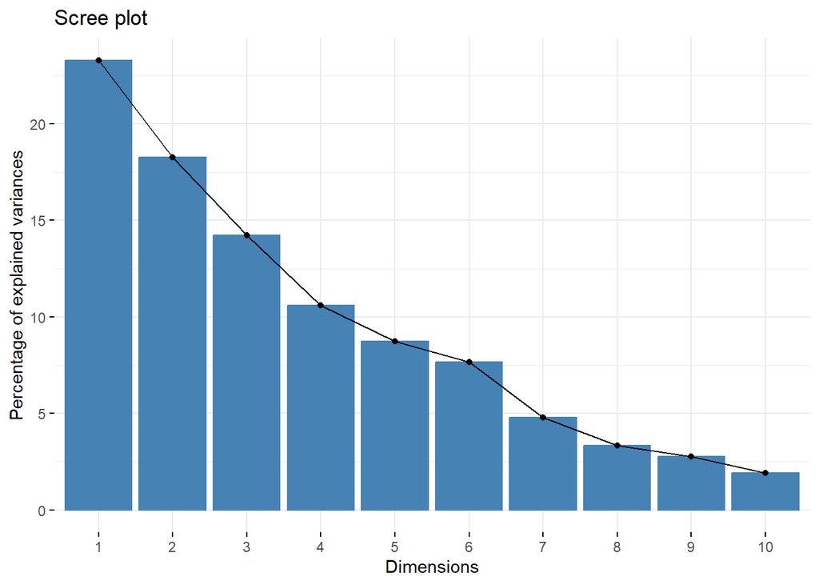

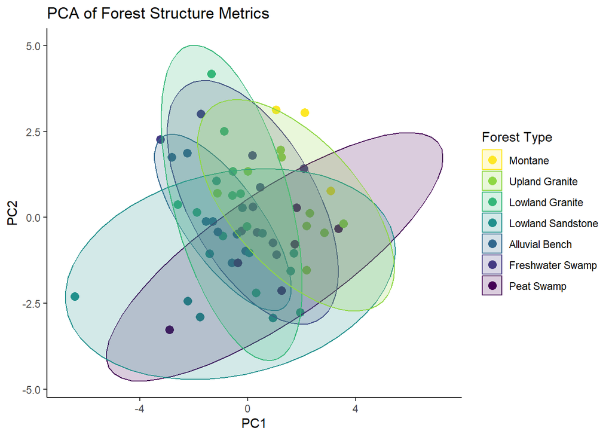

Which structure metrics best differentiate between forest types?

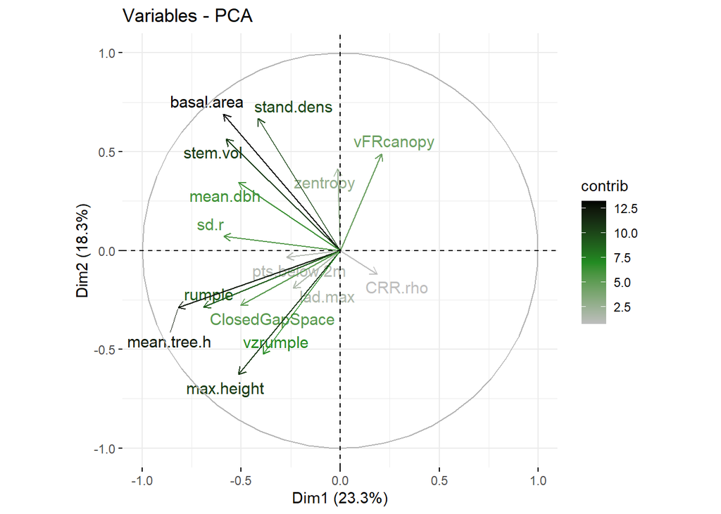